# Part_II_slide_deck_template slides

### A Review of High Impact factors on students' performance in PISA

#### by Oluwasola Aduewa

### Overview

- PISA is a survey of students' skills and knowledge as they approach the end of compulsory education.
- The survey examined how well students have learned the school curriculum and how well prepared they were for life beyond school in 2012.
- Beginning from the variables selection to the exploratory phase of the analysis, the goal was to identify factors at home and in school that influences children's (15- 16 years) performance.

### Dataset

- The PISA dataset contains information on 485,490 students described with 636 variables.
- The dataset has a wealth of information about the family, school, students' personality and many other information surrounding students in their end of compulsory education year.
- The dataset can be found on [Udacity servers](https://www.google.com/url?q=https://s3.amazonaws.com/udacity-hosted-downloads/ud507/pisa2012.csv.zip&sa=D&ust=1581581520574000), and a detailed explanation of all its features can be obtained from this [spreadsheet](https://www.google.com/url?q=https://s3.amazonaws.com/udacity-hosted-downloads/ud507/pisadict2012.csv&sa=D&ust=1554482573645000).

## Concentration:

Accroding to experts, students academic gain and learning performance is affected by numerous factor including gender, students schooling, father/guardian social economic status, medium of instructions in schools,etc. In this presentation They are summed under 3 factors which are

- Home Factor
- School Factor
- Student Motivation

### Home/School

- Home support is good for children and it has a positive influence on their academic performance
- Study materials could be provided by parents or the government depending on the country
- Students succeed when they are equipped with the right study materials: literature, poetry, art, textbooks, technical textbooks, and dictionary
- The combined effect of home support and ownership of the 6 books types has a magical effect on the overall success of students.

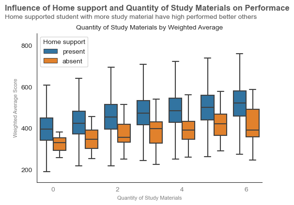

### Student Motivation

- About 80% of students made full attendance in school
- The remaining 20% skipped classes at least once
- Students who are not regular in school are bound to underperform

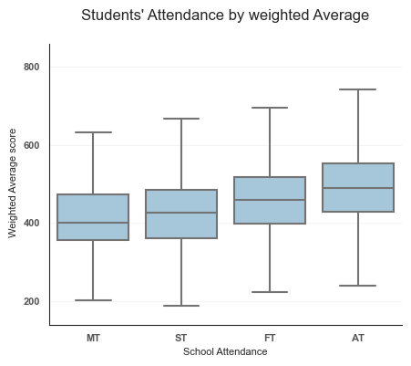

**Keys:** *MT skip classes most of the time, ST skip classes some times, FT skip classes a few times, AT are regular in school*

### Notable features of the truants

- Understanding why truants behave how they behave is key to helping them
- Chronic truants compete highly in a class of students with no books and home support
- A few times truants are worse off compared to chronic truants in performance
- No conclusive evidence to show chronic truants underperform because they skipped classes

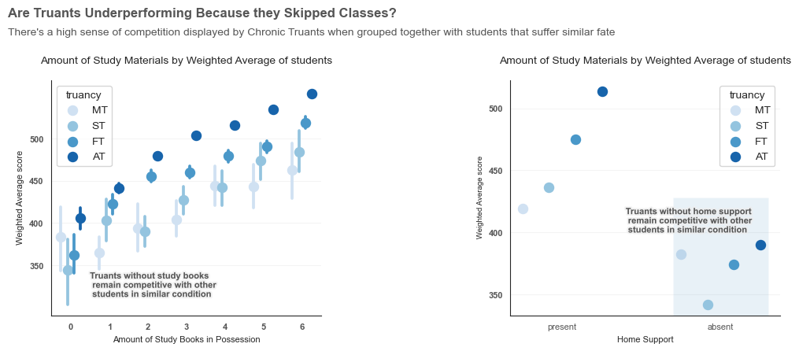

### Final note: group work/ simulation

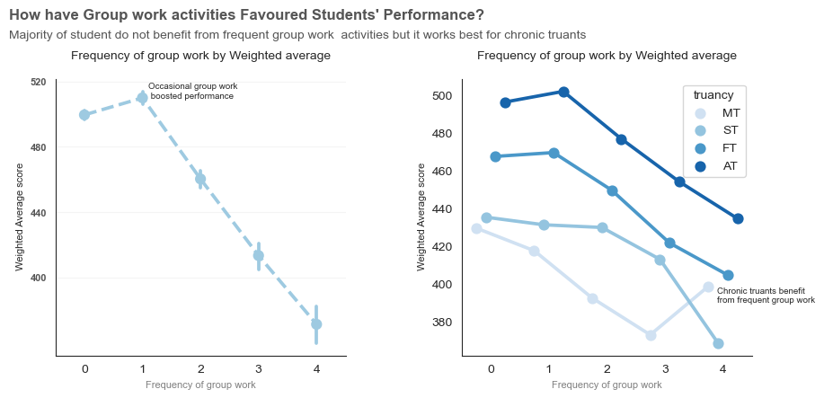

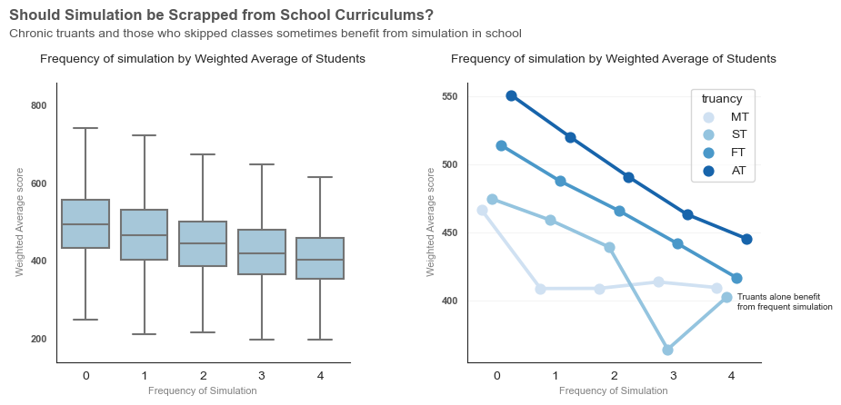